# R

## Do Longer Travel Distance Correlate Win Percentage?

All of the data used in this presentation was imported from the CBS Sports and Official NFL website. Using Python and R, I ran a correlation test and linear regression model to determine if travel distance for NFl teams affects their wins.

The two variables used in the following model are flight distance and win percentage. The model was made with ggplot.

At first glance it looks like the regression curve is flat. This would mean that there is no correlation in either a positive or negative result.

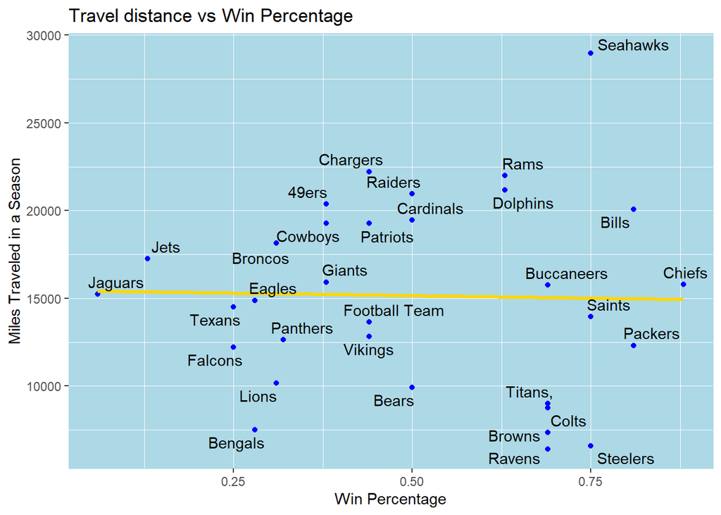

I ran it through the Pearson Correlation Test to get a statistical answer. The Pearson Test is below

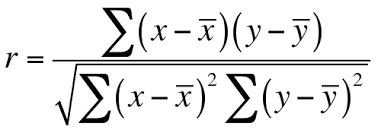

This is R’s version of the test. The R value can be between -1 and 1. Anything below |.3| is little to no correlation, between |.3| and |.7| is a moderate correlation, and greater than |.7| is a strong correlation.

```r
cor.test(data$winpct, data$ miles)
```

```
##
##  Pearson's product-moment correlation
##
## data:  data$winpct and data$miles
## t = -0.1263, df = 30, p-value = 0.9003
## alternative hypothesis: true correlation is not equal to 0
## 95 percent confidence interval:
##  -0.3687828  0.3282796
## sample estimates:
##         cor
## -0.02305329
```

#### References:

cbssports.com

nfl.com